# Telecom Subscriber Churn & ARPU Analytics

Descriptive, Diagnostic, Predictive and Prescriptive Analytics for an Indian Telecom Operator

Author

Souptik De

Published

November 21, 2026

# 1 Business Question, Data and Method

## 1.1 The four questions

This report answers four questions, in order. **Descriptive:** what did churn and ARPU look like in this subscriber base, and what was happening in the Indian market at the same time? **Diagnostic:** which behaviours distinguish churners, holding other things constant? **Predictive:** can we rank subscribers by churn risk before they leave, using only information available at the time? **Prescriptive:** given that ranking, who should receive a retention offer and what is that decision worth?

The customer data comes from one anonymised Indian telecom circle over the June–September 2014 window. The market data comes from 49 quarterly TRAI Performance Indicator reports between 2014 and 2026. They are different objects: the first is a labelled sample of individual lines, the second is the regulator’s national census. The analysis keeps them separate and uses the macro series as context and as a separate time-series investigation, not as extra rows in the customer model.

## 1.2 Data provenance

[output not shown]

`circle_id` equals 109 for every customer row. This is **one service area, not a nationwide sample**, and 69,999 is the competition’s labelled training split rather than a random draw from an operator’s base. All customer-level figures below describe this sample only.

The acquisition and preparation code lives in `scripts/fetch_trai.py`, `scripts/build_trai_series.py` and `scripts/prepare_churn.py`, listed verbatim in the reproducibility appendix. The report itself only reads processed files; it never rewrites data while rendering.

## 1.3 Method map

Every method used below is taught in the Business Analytics notes or case studies: distribution and Pareto analysis, K-means and RFM segmentation (Notes 06, Case 03); confidence intervals, Welch tests, effect sizes and pilot power (Notes 07, Case 04); multiple regression, VIF and dummy variables (Notes 08); logistic regression and odds ratios (Notes 09, Case 01); naive baselines, Holt’s trend, MASE and structural breaks (Notes 10); cross-validation, PR curves, calibration, lift and cost-based thresholds (Notes 11). Random forest appears once as a challenger model — the course churn case study is built on logistic regression — and is evaluated with the same toolkit. No Wilson intervals, Gini coefficients, resampling tests, permutation importance, partial dependence or optimisation solvers are used.

```python
import os
for _v in ("OMP_NUM_THREADS", "OPENBLAS_NUM_THREADS", "MKL_NUM_THREADS"):
    os.environ[_v] = "1"
from pathlib import Path
import warnings
import numpy as np
import pandas as pd
import matplotlib.pyplot as plt
import seaborn as sns
from scipy import stats

warnings.filterwarnings("ignore", category=FutureWarning)
sns.set_theme(style="whitegrid", palette="muted", font_scale=1.0)
plt.rcParams.update({"figure.dpi": 130, "axes.titlesize": 11, "axes.labelsize": 10,
                     "xtick.labelsize": 9, "ytick.labelsize": 9})
BLUE, RED, GREY = "#2b8cbe", "#c51b1d", "#7f8c8d"

def root(rel):
    p = Path(rel)
    return p if p.exists() else Path("..") / rel

def wald(p, n):
    se = np.sqrt(p * (1 - p) / n)
    return p - 1.96 * se, p + 1.96 * se

def rate_row(label, mask, frame):
    s = frame.loc[mask, "churn_probability"]
    lo, hi = wald(s.mean(), len(s))
    return {"Segment": label, "Lines": f"{len(s):,}", "Churn": f"{s.mean():.1%}",
            "95% CI": f"{lo:.1%}–{hi:.1%}"}

df = pd.read_csv(root("data/processed/churn_clean.csv"))
y = df["churn_probability"].astype(int)
N = len(df)
base = y.mean()
df["offnet_share"] = np.where(
    (df.onnet_mou_6.fillna(0) + df.offnet_mou_6.fillna(0)) > 0,
    df.offnet_mou_6.fillna(0) / (df.onnet_mou_6.fillna(0) + df.offnet_mou_6.fillna(0)), np.nan)
df["data_gb"] = (df.vol_2g_mb_6.fillna(0) + df.vol_3g_mb_6.fillna(0)) / 1024
df["rdec"] = pd.qcut(df.avg_rech_amt_6_7, 10, labels=False, duplicates="drop")
# High value is the top 30% of average M6-M7 recharge amount (voice + data
# packs), a cut at the 70th percentile -- not an external competition label.
assert (df.is_high_value == (df.avg_rech_amt_6_7 >= df.avg_rech_amt_6_7.quantile(.7))).all()
```

The competition defines the churn label behaviourally: a subscriber is marked churned when September (M9) shows zero incoming calls, zero outgoing calls and zero data use. The file contains no M9 columns, so the label is taken as given and cannot be re-derived here. June and July (M6/M7) are the “good phase”; August (M8) is the action phase. No M8 column is used as a predictor anywhere in this report; M8 appears only in the descriptive exit analysis.

# 2 Descriptive Analytics

## 2.1 The market around the sample: 2014 to 2026

The customer sample ends in September 2014 — roughly at the peak of the old voice-and-2G pricing model. The regulator’s own series shows what that model became. Reliance Jio launched in September 2016; the vertical line in the next figure marks that quarter.

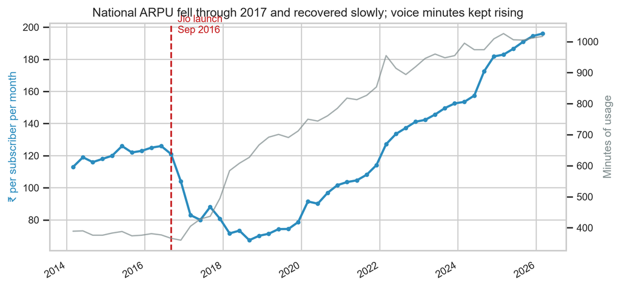

Quarterly national blended ARPU and minutes of usage, 2014–2026

```python
mac = pd.read_csv(root("data/processed/trai_quarterly.csv"))
mac = mac.dropna(subset=["arpu_blended"]).sort_values("quarter_end").reset_index(drop=True)
mac["date"] = pd.to_datetime(mac["quarter_end"] + "-01")
mac["t"] = np.arange(len(mac))

fig, ax = plt.subplots(figsize=(8, 3.8))
ax.plot(mac.date, mac.arpu_blended, color=BLUE, lw=2, marker="o", ms=3, label="Blended ARPU (₹/month)")
ax.axvline(pd.Timestamp("2016-09-01"), color=RED, ls="--", lw=1.5)
ax.text(pd.Timestamp("2016-11-01"), ax.get_ylim()[1]*0.97, "Jio launch\nSep 2016", color=RED, fontsize=9)
ax.set_ylabel("₹ per subscriber per month", color=BLUE)
ax2 = ax.twinx()
ax2.plot(mac.date, mac.mou, color=GREY, lw=1.2, alpha=0.7, label="MOU (min)")
ax2.set_ylabel("Minutes of usage", color=GREY)
ax2.grid(False)
ax.set_title("National ARPU fell through 2017 and recovered slowly; voice minutes kept rising")
fig.autofmt_xdate()
plt.tight_layout()
plt.show()
```

Two anchors carry the revenue-mix story. The figures come from Table 2.3 in each report, which decomposes each rupee of ARPU into rental, calls, SMS, data and other revenue.

```python
# Values transcribed from Table 2.3, TRAI PIR QE Sep-2014 (PDF p.62) and QE Mar-2025 (PDF p.83).
composition = pd.DataFrame([
    ["Blended ARPU (₹/month)",        115.72, 182.95],
    ["Voice: revenue from calls (₹)",  69.35,  15.04],
    ["Voice: share of ARPU",           54.6,    7.91],
    ["Rental revenue (₹)",             19.50,   0.96],
    ["Rental: share of ARPU",          15.3,    0.51],
    ["Data revenue (₹)",               20.48, 164.31],
    ["Data: share of ARPU",            16.1,   86.41],
    ["Data per wireless subscriber (GB/month)", 0.077, 17.03],
    ["Data realisation (₹/GB)",       266.1,    9.11],
    ["Wireless subscribers (million)", 930.20, 1163.76],
], columns=["Metric", "QE Sep-2014", "QE Mar-2025"])
display(composition.round({"QE Sep-2014": 3, "QE Mar-2025": 2}))
```

|  | Metric | QE Sep-2014 | QE Mar-2025 |
| --- | --- | --- | --- |
| 0 | Blended ARPU (₹/month) | 115.720 | 182.95 |
| 1 | Voice: revenue from calls (₹) | 69.350 | 15.04 |
| 2 | Voice: share of ARPU | 54.600 | 7.91 |
| 3 | Rental revenue (₹) | 19.500 | 0.96 |
| 4 | Rental: share of ARPU | 15.300 | 0.51 |
| 5 | Data revenue (₹) | 20.480 | 164.31 |
| 6 | Data: share of ARPU | 16.100 | 86.41 |
| 7 | Data per wireless subscriber (GB/month) | 0.077 | 17.03 |
| 8 | Data realisation (₹/GB) | 266.100 | 9.11 |
| 9 | Wireless subscribers (million) | 930.200 | 1163.76 |

The 2014 volume is TRAI’s 76.97 MB per subscriber per month. The 2025 volume is total wireless data usage (59,447 PB in the quarter) divided by three months and by all 1,163.76 million wireless subscribers. TRAI’s headline 22.19 GB is per *data* subscriber, a smaller denominator, so it is not comparable with the 2014 figure. The 2014 realisation is implied from Table 2.3 (₹20.48 of data revenue ÷ 0.07697 GB); the 2025 figure is TRAI’s published realisation. The two are close but not identical in definition.

Data use per wireless subscriber rose from about 77 MB to 17.0 GB a month — roughly 221× — yet the revenue earned from a gigabyte fell from about ₹266 (implied) to TRAI’s published ₹9.11. Data’s share of ARPU went from 16.1% to 86.4% while voice’s share fell from 54.6% to 7.9%. Total ARPU rose only 58% over eleven years. That is the structural break in one sentence: **the same rupee of ARPU was rebuilt around data at a fraction of the price**. Minutes of usage nearly tripled because calls became bundled and unmetered.

The 2014 retention problem in this report is therefore a voice-era problem. A 2014 operator worried about a subscriber making fewer calls; a 2025 operator worries about monetising a subscriber who uses far more data at a far lower realisation. The churn mechanics are still worth studying — they tell us how a prepaid base behaves — but the economics must not be read as a 2026 price list.

## 2.2 The subscriber base and its KPIs

```python
kpi = pd.DataFrame([
    ["Subscriber lines", f"{N:,}"],
    ["Churners (M9 silence)", f"{int(y.sum()):,}"],
    ["Churn rate", f"{base:.2%}"],
    ["95% CI for churn rate", "{:.2%}–{:.2%}".format(*wald(base, N))],
    ["Mean good-phase ARPU", f"₹{df.avg_arpu_6_7.mean():.2f}"],
    ["Median good-phase ARPU", f"₹{df.avg_arpu_6_7.median():.2f}"],
    ["Mean monthly ARPU, M6", f"₹{df.arpu_6.mean():.2f}"],
    ["Share with any 2G/3G data in M6", f"{(df.data_gb > 0).mean():.1%}"],
    ["Service areas represented", f"{df.circle_id.nunique()} (circle {int(df.circle_id.iloc[0])})"],
], columns=["KPI", "Value"])
display(kpi)
```

|  | KPI | Value |
| --- | --- | --- |
| 0 | Subscriber lines | 69,999 |
| 1 | Churners (M9 silence) | 7,132 |
| 2 | Churn rate | 10.19% |
| 3 | 95% CI for churn rate | 9.96%–10.41% |
| 4 | Mean good-phase ARPU | ₹280.66 |
| 5 | Median good-phase ARPU | ₹198.86 |
| 6 | Mean monthly ARPU, M6 | ₹283.13 |
| 7 | Share with any 2G/3G data in M6 | 23.4% |
| 8 | Service areas represented | 1 (circle 109) |

67.9% of lines bought no data pack in M6 or M7, and 76.6% recorded no 2G/3G data volume in M6; 6,041 lines bought a pack in the window but recorded no M6 volume. The pack fields are blank when nothing was bought, so we treat blanks as zero rather than imputing them away.

## 2.3 Churn and its uncertainty

```python
rows = [rate_row("Whole sample", np.ones(N, dtype=bool), df),
        rate_row("High value (top 30% by recharge)", df.is_high_value == 1, df),
        rate_row("Regular base", df.is_high_value == 0, df),
        rate_row("Tenure < 12 months", df.aon / 30.44 < 12, df),
        rate_row("Any data use in M6", df.data_gb > 0, df),
        rate_row("No data use in M6", df.data_gb == 0, df)]
display(pd.DataFrame(rows))
```

|  | Segment | Lines | Churn | 95% CI |
| --- | --- | --- | --- | --- |
| 0 | Whole sample | 69,999 | 10.2% | 10.0%–10.4% |
| 1 | High value (top 30% by recharge) | 21,013 | 8.3% | 7.9%–8.6% |
| 2 | Regular base | 48,986 | 11.0% | 10.7%–11.3% |
| 3 | Tenure < 12 months | 11,954 | 16.0% | 15.4%–16.7% |
| 4 | Any data use in M6 | 16,414 | 8.4% | 8.0%–8.8% |
| 5 | No data use in M6 | 53,585 | 10.7% | 10.5%–11.0% |

High value here means the top 30% of lines by average monthly recharge amount across M6–M7 (voice plus data packs), a cut at ₹478. This group churns at 8.3% against 11.0% for the rest, and the intervals do not overlap. That is a real difference. Recharge amount is monotonic in churn: 13.3% in the bottom decile versus 7.5% in the top. ARPU is not monotonic — the next section shows its U-shape. The two measures are correlated but not interchangeable, so “target high spenders” works if spend means recharge amount and fails if it means ARPU.

## 2.4 ARPU: a skewed distribution and a concentrated revenue base

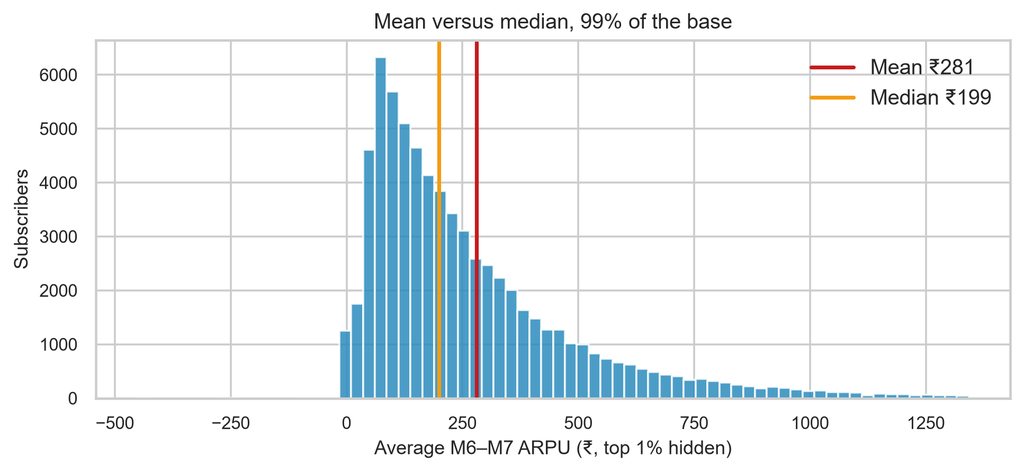

Figure 1: Good-phase ARPU is strongly right-skewed: the mean sits far above the median

```python
fig, ax = plt.subplots(figsize=(7.6, 3.6))
s = df.loc[df.avg_arpu_6_7 <= df.avg_arpu_6_7.quantile(.99), "avg_arpu_6_7"]
ax.hist(s, bins=70, color=BLUE, alpha=.85, edgecolor="white")
ax.axvline(df.avg_arpu_6_7.mean(), color=RED, lw=2, label=f"Mean ₹{df.avg_arpu_6_7.mean():.0f}")
ax.axvline(df.avg_arpu_6_7.median(), color="#f39c12", lw=2, label=f"Median ₹{df.avg_arpu_6_7.median():.0f}")
ax.set_xlabel("Average M6–M7 ARPU (₹, top 1% hidden)")
ax.set_ylabel("Subscribers")
ax.set_title("Mean versus median, 99% of the base")
ax.legend(frameon=False)
plt.tight_layout()
plt.show()
```

The mean (₹281) is ₹82 above the median (₹199); the largest single account bills over ₹30,000 a month. Any offer priced off the mean is priced for a customer who does not exist.

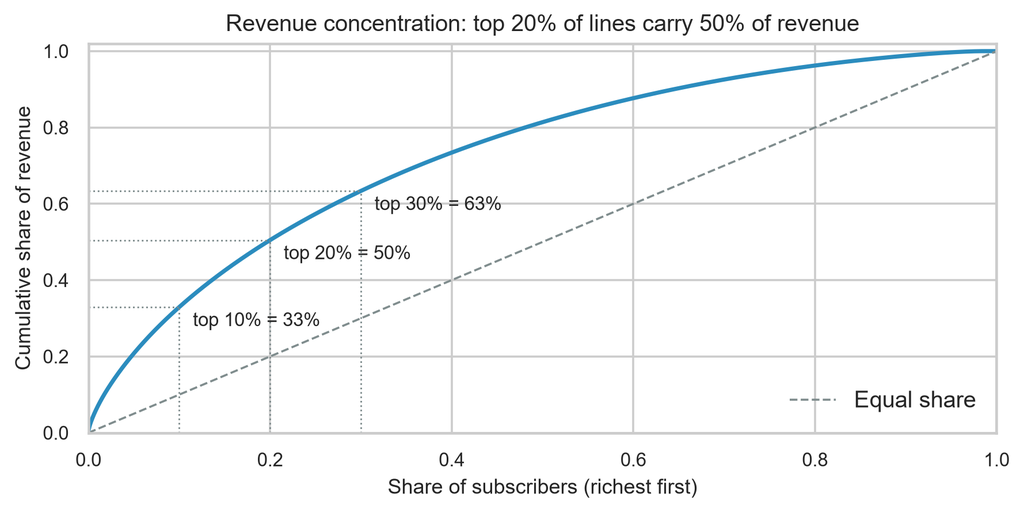

Figure 2: Cumulative share of good-phase revenue, subscribers ranked by ARPU

```python
rev = np.sort(df.avg_arpu_6_7.values)[::-1]
cum = np.cumsum(rev) / rev.sum()
frac = np.arange(1, len(rev) + 1) / len(rev)
fig, ax = plt.subplots(figsize=(7, 3.6))
ax.plot(frac, cum, color=BLUE, lw=2)
ax.plot([0, 1], [0, 1], color=GREY, ls="--", lw=1, label="Equal share")
for p in [.1, .2, .3]:
    ax.plot([p, p], [0, cum[int(N*p)-1]], color=GREY, lw=.8, ls=":")
    ax.plot([0, p], [cum[int(N*p)-1]]*2, color=GREY, lw=.8, ls=":")
    ax.text(p+.015, cum[int(N*p)-1]-.05, f"top {p:.0%} = {cum[int(N*p)-1]:.0%}", fontsize=9)
ax.set_xlim(0, 1); ax.set_ylim(0, 1.02)
ax.set_xlabel("Share of subscribers (richest first)")
ax.set_ylabel("Cumulative share of revenue")
ax.set_title(f"Revenue concentration: top 20% of lines carry {cum[int(N*.2)-1]:.0%} of revenue")
ax.legend(frameon=False, loc="lower right")
plt.tight_layout()
plt.show()
```

The familiar 80/20 slogan is wrong for this base. The top 20% carry 50.5% of revenue, the top 30% carry 63.4%, and the bottom half carry 18.6%. Revenue is concentrated, but not 80/20 concentrated. Pareto’s “vital few” is the right idea; the exact fraction has to be measured.

## 2.5 Who churns: four curves that are not straight

The descriptive chapter’s main finding is that **no simple “more is better” story fits this base**. Four independent cuts all bend.

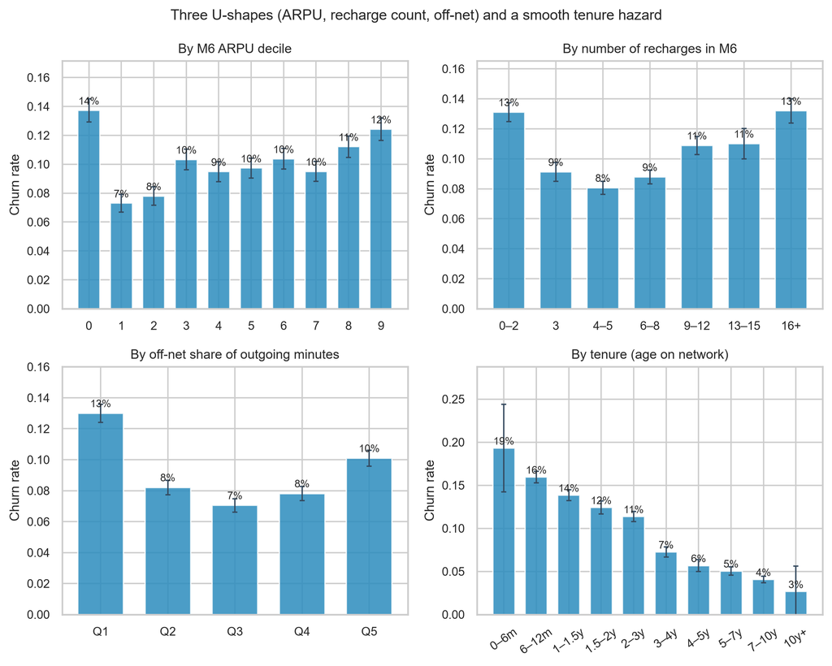

Figure 3: Churn by starting ARPU, recharge frequency, off-net share and tenure — all four are non-monotonic or curved

```python
df["arpu_dec"] = pd.qcut(df.arpu_6, 10, labels=False, duplicates="drop")
df["rech_bin"] = pd.cut(df.total_rech_num_6, [-1,2,3,5,8,12,15,100],
                        labels=["0–2","3","4–5","6–8","9–12","13–15","16+"])
df["off_q"] = pd.qcut(df.offnet_share, 5, labels=["Q1","Q2","Q3","Q4","Q5"], duplicates="drop")
df["ten_bin"] = pd.cut(df.aon/30.44, [0,6,12,18,24,36,48,60,84,120,10000],
                       labels=["0–6m","6–12m","1–1.5y","1.5–2y","2–3y","3–4y","4–5y","5–7y","7–10y","10y+"], right=False)
arpu_by_ten = df.groupby("ten_bin", observed=True).avg_arpu_6_7.mean()

def plot_rate(ax, col, title, rotate=0):
    g = df.groupby(col, observed=True).churn_probability.agg(["mean","size"])
    xs = np.arange(len(g))
    lo, hi = zip(*[wald(v, n) for v, n in zip(g["mean"], g["size"])])
    ax.bar(xs, g["mean"], color=BLUE, alpha=.85, width=.68)
    ax.errorbar(xs, g["mean"], yerr=[g["mean"]-lo, hi-g["mean"]], fmt="none", ecolor="#34495e", capsize=2, lw=1)
    ax.set_xticks(xs); ax.set_xticklabels([str(x) for x in g.index], rotation=rotate)
    ax.set_ylim(0, max(hi)*1.18)
    ax.set_ylabel("Churn rate")
    ax.set_title(title, fontsize=10)
    for xi, v in zip(xs, g["mean"]):
        ax.text(xi, v+.004, f"{v:.0%}", ha="center", fontsize=8)

fig, axes = plt.subplots(2, 2, figsize=(9, 7.2))
plot_rate(axes[0,0], "arpu_dec", "By M6 ARPU decile")
plot_rate(axes[0,1], "rech_bin", "By number of recharges in M6")
plot_rate(axes[1,0], "off_q", "By off-net share of outgoing minutes")
plot_rate(axes[1,1], "ten_bin", "By tenure (age on network)", rotate=35)
fig.suptitle("Three U-shapes (ARPU, recharge count, off-net) and a smooth tenure hazard", fontsize=11)
plt.tight_layout()
plt.show()
```

- **ARPU.** The bottom decile churns at 13.7% and the top decile at 12.4%, while the middle deciles sit around 7–10%. “High spend protects” is only true if you stop at the 70th percentile and never look at the tail.
- **Recharge frequency.** Both extremes churn: 0–2 recharges 13.1%, 4–5 recharges 8.1%, 16+ recharges 13.2%. The average maximum recharge amount is ₹84 in the 16+ group versus ₹118 in the 4–5 group: many small top-ups look like hand-to-mouth balance management, not engagement. This is why the older notebook’s claim that “low frequency churns more than high” was wrong.
- **Off-net calling.** Subscribers whose outgoing minutes are mostly to other networks sit at the low and high ends of the churn curve; the middle quintile is the stickiest. Those with almost no outgoing minutes are disengaged; those with almost entirely off-net minutes have little reason to stay with this operator.
- **Tenure.** The hazard falls smoothly from 19.3% in the first six months to 4.1% at seven to ten years. ARPU is roughly flat across the first nine bins (₹259–₹295) and rises only in the 10-year-plus bin (₹354); the churn decline is an age effect, not a simple value effect.

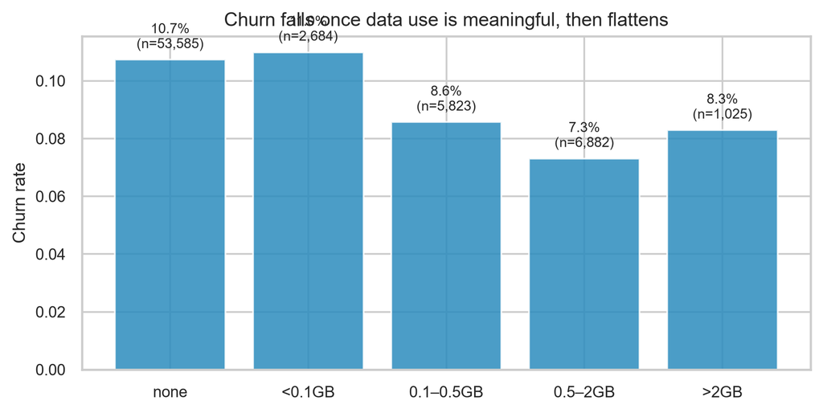

Figure 4: Any data use lowers churn, but heavier use does not monotonically lower it further

```python
df["data_bin"] = pd.cut(df.data_gb, [-.001, 0, .1, .5, 2, 1e6], labels=["none","<0.1GB","0.1–0.5GB","0.5–2GB",">2GB"])
g = df.groupby("data_bin", observed=True).agg(churn=("churn_probability","mean"), arpu=("avg_arpu_6_7","mean"), n=("id","size"))
fig, ax = plt.subplots(figsize=(6.8, 3.5))
ax.bar(g.index.astype(str), g.churn, color=BLUE, alpha=.85)
ax.set_ylabel("Churn rate"); ax.set_title("Churn falls once data use is meaningful, then flattens")
for i,(v,n) in enumerate(zip(g.churn,g.n)):
    ax.text(i, v+.004, f"{v:.1%}\n(n={n:,})", ha="center", fontsize=8)
plt.tight_layout(); plt.show()
```

Churn is flat from no data (10.7%) to under 0.1 GB (11.0%), falls to 8.6% at 0.1–0.5 GB and 7.3% at 0.5–2 GB, then ticks back up to 8.3% above 2 GB. The retention benefit comes from meaningful data use, not from a token pack; the >2 GB group has much higher ARPU but no extra retention benefit. In a market where data became the product, this 2014 sample still behaves like a voice base with an optional add-on.

## 2.6 Behavioural segments

K-means on standardised tenure, ARPU, recharge count, outgoing and incoming minutes, data volume and off-net share gives the strongest split at k=2 (silhouette 0.40); k=4 is weaker (0.25) but separates four actionable groups. RFM quintiles on recency, frequency and monetary value are the transparent cross-check taught in the case studies.

```python
from sklearn.preprocessing import StandardScaler
from sklearn.cluster import KMeans
from sklearn.metrics import silhouette_score
num = pd.DataFrame({"arpu_100": df.arpu_6/100,
                    "arpu_drop_100": -df.arpu_diff_7_6/100,
                    "tenure_year": df.aon/365.25,
                    "recharges": df.total_rech_num_6,
                    "og_100min": df.total_og_mou_6/100,
                    "ic_100min": df.total_ic_mou_6/100,
                    "offnet_10pp": df.offnet_share.fillna(df.offnet_share.median())*10,
                    "data_gb": df.data_gb,
                    "data_plan": df.has_data_plan})
kcols = ["arpu_100","recharges","og_100min","ic_100min","data_gb","offnet_10pp","tenure_year"]
Z = StandardScaler().fit_transform(num[kcols].fillna(num[kcols].median()))
sil = {k: silhouette_score(Z, KMeans(n_clusters=k, n_init=10, random_state=42).fit_predict(Z))
       for k in [2, 3, 4]}
print("silhouette by k:", {k: round(v,3) for k,v in sil.items()})
df["cluster"] = KMeans(n_clusters=4, n_init=10, random_state=42).fit_predict(Z)
prof = df.groupby("cluster").agg(lines=("id","size"), churn=("churn_probability","mean"),
                                 arpu=("avg_arpu_6_7","mean"), tenure_yr=("aon",lambda s:s.mean()/365.25),
                                 recharges=("total_rech_num_6","mean"), data_gb=("data_gb","mean"),
                                 offnet=("offnet_share","mean"), revenue=("avg_arpu_6_7","sum"))
prof["revenue_share"] = prof.revenue/prof.revenue.sum()
display(prof.round(3))
```

```
silhouette by k: {2: 0.401, 3: 0.238, 4: 0.247}
```

| cluster | lines | churn | arpu | tenure_yr | recharges | data_gb | offnet | revenue | revenue_share |
| --- | --- | --- | --- | --- | --- | --- | --- | --- | --- |
| 0 | 16193 | 0.043 | 246.633 | 7.231 | 5.502 | 0.120 | 0.745 | 3993734.166 | 0.203 |
| 1 | 7486 | 0.128 | 797.526 | 2.848 | 19.271 | 0.450 | 0.629 | 5970280.494 | 0.304 |
| 2 | 32343 | 0.115 | 191.806 | 1.922 | 5.930 | 0.169 | 0.842 | 6203571.851 | 0.316 |
| 3 | 13977 | 0.127 | 248.862 | 2.387 | 7.475 | 0.080 | 0.279 | 3478342.512 | 0.177 |

```python
df["recency_days"] = (pd.to_datetime(df.last_date_of_month_6, format="%m/%d/%Y", errors="coerce")
                      - pd.to_datetime(df.date_of_last_rech_6, format="%m/%d/%Y", errors="coerce")).dt.days.fillna(30)
for col, name in [("total_rech_num_6","F"),("total_rech_amt_6","M")]:
    df[name] = pd.qcut(df[col].rank(method="first"), 5, labels=[1,2,3,4,5]).astype(int)
df["R"] = pd.qcut(df.recency_days.rank(method="first"), 5, labels=[5,4,3,2,1]).astype(int)
rfm = pd.DataFrame([rate_row(f"Recency {i}", df.R==i, df) for i in range(1,6)] +
                   [rate_row(f"Frequency {i}", df.F==i, df) for i in range(1,6)] +
                   [rate_row(f"Monetary {i}", df.M==i, df) for i in range(1,6)])
display(rfm)
```

|  | Segment | Lines | Churn | 95% CI |
| --- | --- | --- | --- | --- |
| 0 | Recency 1 | 14,000 | 12.7% | 12.2%–13.3% |
| 1 | Recency 2 | 14,000 | 9.9% | 9.4%–10.4% |
| 2 | Recency 3 | 13,999 | 9.4% | 8.9%–9.9% |
| 3 | Recency 4 | 14,000 | 9.5% | 9.1%–10.0% |
| 4 | Recency 5 | 14,000 | 9.4% | 8.9%–9.8% |
| 5 | Frequency 1 | 14,000 | 12.1% | 11.6%–12.6% |
| 6 | Frequency 2 | 14,000 | 8.7% | 8.2%–9.2% |
| 7 | Frequency 3 | 13,999 | 8.0% | 7.6%–8.5% |
| 8 | Frequency 4 | 14,000 | 10.1% | 9.6%–10.6% |
| 9 | Frequency 5 | 14,000 | 12.0% | 11.5%–12.6% |
| 10 | Monetary 1 | 14,000 | 11.4% | 10.9%–11.9% |
| 11 | Monetary 2 | 14,000 | 8.9% | 8.5%–9.4% |
| 12 | Monetary 3 | 13,999 | 9.4% | 8.9%–9.9% |
| 13 | Monetary 4 | 14,000 | 9.6% | 9.2%–10.1% |
| 14 | Monetary 5 | 14,000 | 11.5% | 11.0%–12.1% |

K-means does not discover exotic types; it rediscovers tenure and value. With `n_init=10` the four clusters are: a long-tenure, low-churn group (16,193 lines, 7.2 years on network, 4.3% churn); a small high-ARPU, high-recharge group (7,486 lines, ₹798 a month, 19 recharges, 12.8% churn); and two younger groups (1.9 and 2.4 years, ₹192 and ₹249) that split almost entirely on off-net share (0.84 versus 0.28) and both churn at 11.5–12.7%. RFM partly agrees and partly disagrees: the least-recent quintile churns at 12.7% versus 9.4% for the most recent, as expected, but the *most* frequent and *highest*-spend quintiles churn at 12.0% and 11.5% — the middle quintiles are safer. That disagreement is the useful result: the expensive clustering adds no segment that a simple RFM score would miss, and the playbook can be written in plain recency/frequency/value language.

## 2.7 Descriptive findings

1. Churn is 10.2% of this sample (7,132 lines), with a 95% CI of 10.0%–10.4%.
2. The average customer is misleading: mean good-phase ARPU is ₹281, median ₹199, and the top 20% of lines carry 50% of revenue — not 80%.
3. Risk is U-shaped in ARPU and recharge frequency, but monotonic in recharge amount and tenure. “Target high spenders” works if spend means recharge amount; it fails if spend means ARPU.
4. National data revenue per GB fell from roughly ₹266 (implied) to ₹9.11 (published) between 2014 and 2025 while data’s share of ARPU rose from 16% to 86%. The market that produced this sample no longer exists in the same economic form.

# 3 Diagnostic Analytics

## 3.1 Hypotheses

The descriptive curves suggest four claims worth testing, all using M6/M7 information only:

1. Churners are **younger on the network** (tenure d < 0).
2. Churners **receive fewer incoming minutes** — they are losing their calling circle.
3. Churners show a **drop within the good phase**: M7 ARPU below M6 ARPU, even though their M6 level is not lower.
4. **Data adoption and high value are protective**, but the descriptive U-shapes warn that value is not protective at the very top.

For categorical comparisons with two levels we use the two-sample version of the Notes 07 proportion standard error; for continuous variables, Welch’s t-test with a 95% CI on the mean difference and Cohen’s d. Effect size matters more than the p-value at n = 70,000: a statistically significant 0.2-point difference is not a business finding.

## 3.2 Univariate evidence

```python
def welch_row(col, label):
    a = df.loc[y == 0, col].dropna(); b = df.loc[y == 1, col].dropna()
    t, p = stats.ttest_ind(a, b, equal_var=False)
    pooled = np.sqrt(((len(a)-1)*a.var(ddof=1) + (len(b)-1)*b.var(ddof=1))/(len(a)+len(b)-2))
    d = (b.mean()-a.mean())/pooled if pooled > 0 else np.nan
    se = np.sqrt(a.var(ddof=1)/len(a) + b.var(ddof=1)/len(b))
    diff = b.mean()-a.mean()
    return {"Variable": label, "Retained": f"{a.mean():.2f}", "Churned": f"{b.mean():.2f}",
            "Difference": f"{diff:+.2f}", "95% CI": f"{diff-1.96*se:+.2f} to {diff+1.96*se:+.2f}",
            "p": f"{p:.1e}", "Cohen d": f"{d:+.3f}"}

tests = [welch_row(c, l) for c, l in [
    ("aon", "Age on network (days)"),
    ("arpu_6", "ARPU in M6 (₹)"),
    ("arpu_7", "ARPU in M7 (₹)"),
    ("total_ic_mou_6", "Incoming minutes M6"),
    ("total_ic_mou_7", "Incoming minutes M7"),
    ("total_og_mou_6", "Outgoing minutes M6"),
    ("total_rech_num_6", "Recharges M6"),
    ("data_gb", "Data volume M6 (GB)"),
    ("offnet_share", "Off-net share of outgoing M6")]]
display(pd.DataFrame(tests))
```

|  | Variable | Retained | Churned | Difference | 95% CI | p | Cohen d |
| --- | --- | --- | --- | --- | --- | --- | --- |
| 0 | Age on network (days) | 1264.00 | 838.40 | -425.60 | -444.24 to -406.97 | 0.0e+00 | -0.451 |
| 1 | ARPU in M6 (₹) | 280.28 | 308.29 | +28.01 | +18.70 to +37.32 | 3.9e-09 | +0.084 |
| 2 | ARPU in M7 (₹) | 284.89 | 219.08 | -65.81 | -73.75 to -57.87 | 1.5e-58 | -0.191 |
| 3 | Incoming minutes M6 | 206.64 | 138.60 | -68.05 | -74.91 to -61.18 | 2.3e-82 | -0.235 |
| 4 | Incoming minutes M7 | 213.89 | 95.97 | -117.92 | -123.71 to -112.13 | 0.0e+00 | -0.400 |
| 5 | Outgoing minutes M6 | 301.24 | 352.37 | +51.13 | +37.48 to +64.78 | 2.3e-13 | +0.110 |
| 6 | Recharges M6 | 7.50 | 8.11 | +0.60 | +0.41 to +0.80 | 2.9e-09 | +0.086 |
| 7 | Data volume M6 (GB) | 0.17 | 0.14 | -0.04 | -0.05 to -0.02 | 1.2e-07 | -0.064 |
| 8 | Off-net share of outgoing M6 | 0.68 | 0.63 | -0.05 | -0.06 to -0.04 | 5.2e-31 | -0.176 |

Two results deserve attention. First, **churners had higher M6 ARPU** than retained lines (₹308 versus ₹280), though the effect is negligible (d ≈ +0.08). By M7 the sign has flipped and the effect is small but real (d ≈ −0.19). The signal is the **change**, not the level. Second, the largest standardised differences are tenure (d ≈ −0.45) and incoming minutes (d ≈ −0.24 to −0.40 depending on month); the rest are small. High M6 outgoing minutes also show a *positive* association with churn — heavy calling, by itself, is not loyalty.

```python
def prop_row(mask, label):
    a, b = y[mask], y[~mask]
    p1, p2 = a.mean(), b.mean()
    se = np.sqrt(p1*(1-p1)/len(a) + p2*(1-p2)/len(b))
    z = (p1-p2)/se
    return {"Comparison": label, "Rate A": f"{p1:.1%}", "Rate B": f"{p2:.1%}",
            "Difference": f"{(p1-p2)*100:+.2f} pp", "z": f"{z:+.2f}", "p": f"{2*stats.norm.sf(abs(z)):.1e}"}

props = [prop_row(df.is_high_value==1, "High value vs rest"),
         prop_row(df.has_data_plan==1, "Data plan vs none"),
         prop_row(df.aon/30.44<12, "Tenure < 1 year vs older"),
         prop_row(df.total_rech_num_6<=3, "≤3 recharges vs more"),
         prop_row(df.total_rech_num_6>=13, "≥13 recharges vs fewer"),
         prop_row(df.offnet_share>=0.9, "≥90% off-net calls vs fewer")]
display(pd.DataFrame(props))
```

|  | Comparison | Rate A | Rate B | Difference | z | p |
| --- | --- | --- | --- | --- | --- | --- |
| 0 | High value vs rest | 8.3% | 11.0% | -2.73 pp | -11.54 | 8.5e-31 |
| 1 | Data plan vs none | 8.7% | 10.9% | -2.17 pp | -9.18 | 4.3e-20 |
| 2 | Tenure < 1 year vs older | 16.0% | 9.0% | +7.02 pp | +19.74 | 1.1e-86 |
| 3 | ≤3 recharges vs more | 11.4% | 9.7% | +1.69 pp | +6.37 | 1.8e-10 |
| 4 | ≥13 recharges vs fewer | 12.4% | 9.8% | +2.63 pp | +7.64 | 2.2e-14 |
| 5 | ≥90% off-net calls vs fewer | 9.7% | 10.4% | -0.69 pp | -2.66 | 7.9e-03 |

## 3.3 Multivariable evidence: holding other things constant

The univariate tests cannot separate age from value or calling pattern. A logistic GLM on the natural (odds-ratio) scale does. The model uses non-collinear M6/M7 features: VIFs are all below 2.4, so no coefficient is being distorted by redundancy. We drop `aon`/`tenure_months` duplicates and the averaged-ARPU columns for this model.

```python
import statsmodels.api as sm
from statsmodels.stats.outliers_influence import variance_inflation_factor
Xg = pd.DataFrame({
    "ARPU per ₹100 (M6)": df.arpu_6/100,
    "ARPU drop per ₹100 (M7−M6)": -df.arpu_diff_7_6/100,
    "Tenure per year": df.aon/365.25,
    "Recharges in M6": df.total_rech_num_6,
    "Outgoing per 100 min": df.total_og_mou_6/100,
    "Incoming per 100 min": df.total_ic_mou_6/100,
    "Off-net per 10 pp": df.offnet_share.fillna(df.offnet_share.median())*10,
    "Data per GB": df.data_gb,
    "Has data plan": df.has_data_plan})
Xg = sm.add_constant(Xg)
glm = sm.Logit(y, Xg).fit(disp=0)
ci = glm.conf_int()
orb = pd.DataFrame({"Odds ratio": np.exp(glm.params), "Lower": np.exp(ci[0]),
                    "Upper": np.exp(ci[1]), "p": glm.pvalues})
display(orb.round(4))
vif = pd.DataFrame({"Feature": Xg.columns[1:],
                    "VIF": [variance_inflation_factor(Xg.drop(columns="const").fillna(0).values, i)
                            for i in range(Xg.shape[1]-1)]})
print("All VIF < 2.4 — no multicollinearity problem (rule of thumb: >5 concerns, >10 serious).")
print(f"Pseudo R² = {glm.prsquared:.3f}")
```

|  | Odds ratio | Lower | Upper | p |
| --- | --- | --- | --- | --- |
| const | 0.3149 | 0.2910 | 0.3408 | 0.0000 |
| ARPU per ₹100 (M6) | 0.9769 | 0.9615 | 0.9924 | 0.0037 |
| ARPU drop per ₹100 (M7−M6) | 1.2239 | 1.2066 | 1.2415 | 0.0000 |
| Tenure per year | 0.8141 | 0.8036 | 0.8248 | 0.0000 |
| Recharges in M6 | 0.9961 | 0.9920 | 1.0002 | 0.0597 |
| Outgoing per 100 min | 1.0097 | 1.0018 | 1.0177 | 0.0157 |
| Incoming per 100 min | 0.8836 | 0.8705 | 0.8969 | 0.0000 |
| Off-net per 10 pp | 0.9745 | 0.9659 | 0.9832 | 0.0000 |
| Data per GB | 0.8476 | 0.7948 | 0.9039 | 0.0000 |
| Has data plan | 0.8514 | 0.7985 | 0.9079 | 0.0000 |

```
All VIF < 2.4 — no multicollinearity problem (rule of thumb: >5 concerns, >10 serious).
Pseudo R² = 0.067
```

```python
# A logit is linear in the log-odds by construction. Test whether that restriction
# fits before treating the odds ratios as constant marginal effects.
Xq = Xg.copy()
for f in ["ARPU per ₹100 (M6)", "ARPU drop per ₹100 (M7−M6)", "Tenure per year",
          "Recharges in M6", "Outgoing per 100 min", "Incoming per 100 min"]:
    Xq[f + " squared"] = Xg[f] ** 2
glm_q = sm.Logit(y, Xq).fit(disp=0)
lr_q = 2 * (glm_q.llf - glm.llf)
df_q = Xq.shape[1] - Xg.shape[1]
p_q = stats.chi2.sf(lr_q, df_q)

# Flexible alternative: decile/band dummies for the three visibly curved drivers.
ten_band = pd.cut(df.aon / 365.25, [0, 1, 2, 3, 4, 5, 7, 10, 60],
                  labels=["<1", "1–2", "2–3", "3–4", "4–5", "5–7", "7–10", "10+"])
Xf = pd.get_dummies(pd.DataFrame({"ARPU decile": pd.Categorical(df.arpu_dec),
                                  "Tenure band": pd.Categorical(ten_band),
                                  "Recharge bin": pd.Categorical(df.rech_bin)}),
                    drop_first=True, dtype=float)
Xf["ARPU drop per ₹100"] = -df.arpu_diff_7_6 / 100
Xf["Outgoing per 100 min"] = df.total_og_mou_6 / 100
Xf["Incoming per 100 min"] = df.total_ic_mou_6 / 100
Xf["Off-net per 10 pp"] = df.offnet_share.fillna(df.offnet_share.median()) * 10
Xf["Data per GB"] = df.data_gb
Xf["Has data plan"] = df.has_data_plan
Xf = sm.add_constant(Xf)
glm_f = sm.Logit(y, Xf).fit(disp=0)
lr_f = 2 * (glm_f.llf - glm.llf)
df_f = Xf.shape[1] - Xg.shape[1]
p_f = stats.chi2.sf(lr_f, df_f)
print(f"Quadratic terms: LR = {lr_q:.1f}, df = {df_q}, p = {p_q:.1e}")
print(f"Binned model:    LR = {lr_f:.1f}, df = {df_f}, p = {p_f:.1e}")

lin_p = glm.predict(Xg)
flex_p = glm_f.predict(Xf)
fit_by_tenure = (pd.DataFrame({"Band": ten_band, "Observed": y, "Linear": lin_p, "Flexible": flex_p})
                 .groupby("Band", observed=True).mean().round(3))
fit_by_arpu = (pd.DataFrame({"Decile": df.arpu_dec + 1, "Observed": y, "Linear": lin_p, "Flexible": flex_p})
               .groupby("Decile").mean().round(3))
print("\nChurn by tenure band (observed vs fitted):")
display(fit_by_tenure)
print("Churn by M6 ARPU decile (observed vs fitted):")
display(fit_by_arpu)

ci_f = glm_f.conf_int()
flex_or = pd.DataFrame({"Odds ratio": np.exp(glm_f.params),
                        "Lower": np.exp(ci_f[0]), "Upper": np.exp(ci_f[1]),
                        "p": glm_f.pvalues}).loc[
    ["ARPU drop per ₹100", "Outgoing per 100 min", "Incoming per 100 min",
     "Off-net per 10 pp", "Data per GB", "Has data plan"]]
display(flex_or.round(3))
```

```
Quadratic terms: LR = 481.4, df = 6, p = 8.4e-101
Binned model:    LR = 294.4, df = 19, p = 2.8e-51

Churn by tenure band (observed vs fitted):
```

| Band | Observed | Linear | Flexible |
| --- | --- | --- | --- |
| <1 | 0.160 | 0.153 | 0.160 |
| 1–2 | 0.133 | 0.133 | 0.133 |
| 2–3 | 0.114 | 0.109 | 0.114 |
| 3–4 | 0.072 | 0.089 | 0.072 |
| 4–5 | 0.057 | 0.073 | 0.057 |
| 5–7 | 0.050 | 0.052 | 0.050 |
| 7–10 | 0.041 | 0.033 | 0.041 |
| 10+ | 0.027 | 0.018 | 0.027 |

```
Churn by M6 ARPU decile (observed vs fitted):
```

| Decile | Observed | Linear | Flexible |
| --- | --- | --- | --- |
| 1 | 0.137 | 0.107 | 0.137 |
| 2 | 0.073 | 0.097 | 0.073 |
| 3 | 0.078 | 0.097 | 0.078 |
| 4 | 0.103 | 0.101 | 0.103 |
| 5 | 0.095 | 0.098 | 0.095 |
| 6 | 0.097 | 0.100 | 0.097 |
| 7 | 0.104 | 0.099 | 0.104 |
| 8 | 0.095 | 0.098 | 0.095 |
| 9 | 0.112 | 0.103 | 0.112 |
| 10 | 0.124 | 0.119 | 0.124 |

|  | Odds ratio | Lower | Upper | p |
| --- | --- | --- | --- | --- |
| ARPU drop per ₹100 | 1.210 | 1.194 | 1.226 | 0.000 |
| Outgoing per 100 min | 0.995 | 0.988 | 1.003 | 0.227 |
| Incoming per 100 min | 0.887 | 0.873 | 0.900 | 0.000 |
| Off-net per 10 pp | 0.971 | 0.963 | 0.980 | 0.000 |
| Data per GB | 0.813 | 0.762 | 0.868 | 0.000 |
| Has data plan | 0.839 | 0.786 | 0.895 | 0.000 |

## 3.4 Two ways of leaving

The mean ARPU collapse hides two different processes. 38.0% of churners have **zero** August ARPU; the rest fade but keep spending.

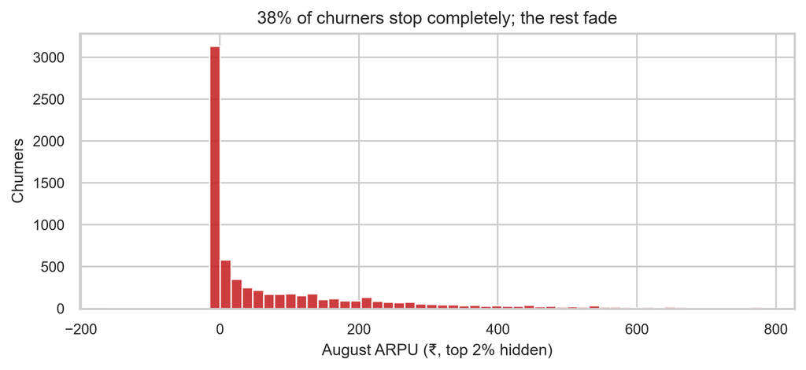

August ARPU among churners: an abrupt-stop spike at zero and a slower fade

|  | Exit style | Churners | Median M7 ARPU (₹) | Mean M7 ARPU (₹) |
| --- | --- | --- | --- | --- |
| 0 | Abrupt (M8 ARPU = 0) | 2,709 | 33.5 | 121.3 |
| 1 | Fade (M8 ARPU > 0) | 4,226 | 183.8 | 285.6 |

```python
ch = df[y == 1]
fig, ax = plt.subplots(figsize=(7.2, 3.4))
ax.hist(ch.loc[ch.arpu_8 <= ch.arpu_8.quantile(.98), "arpu_8"], bins=60, color=RED, alpha=.85, edgecolor="white")
ax.set_xlabel("August ARPU (₹, top 2% hidden)"); ax.set_ylabel("Churners")
ax.set_title(f"{(ch.arpu_8==0).mean():.0%} of churners stop completely; the rest fade")
plt.tight_layout(); plt.show()
summary = pd.DataFrame([
    ["Abrupt (M8 ARPU = 0)", f"{(ch.arpu_8==0).sum():,}", f"{ch.loc[ch.arpu_8==0,'arpu_7'].median():.1f}", f"{ch.loc[ch.arpu_8==0,'arpu_7'].mean():.1f}"],
    ["Fade (M8 ARPU > 0)", f"{(ch.arpu_8>0).sum():,}", f"{ch.loc[ch.arpu_8>0,'arpu_7'].median():.1f}", f"{ch.loc[ch.arpu_8>0,'arpu_7'].mean():.1f}"],
], columns=["Exit style", "Churners", "Median M7 ARPU (₹)", "Mean M7 ARPU (₹)"])
display(summary)
```

Among all churners the median ARPU falls from ₹211 in June to ₹118 in July and ₹10 in August — a 95% collapse — while the mean falls 63%. The old report quoted only the mean. The mixture explains the gap: one group halts in a single step, the other declines gradually. Only 1.9% of retained subscribers have zero August ARPU, so the spike is specific to churners. This is a descriptive observation, not a causal claim: because churn is *defined* by September silence, some of the August decay is the same disengagement process seen one month earlier.

## 3.5 What the Jio break did to the market series

The macro series is a genuine quarterly time series, so it can be tested rather than merely narrated. First, does it have a seasonal pattern? We regress ARPU on a linear trend and three quarter dummies and test the dummies jointly. Second, is there a level shift at Sep-2016? We fit ARPU on time plus a post-launch dummy and a post-launch slope. Third, do the standard forecasting methods beat a naive baseline? We compare naive, Holt’s linear trend and Holt–Winters using MASE on the final ten quarters (2023-12 to 2026-03), which are held out from fitting.

```python
from statsmodels.tsa.holtwinters import Holt, ExponentialSmoothing
from statsmodels.stats.stattools import durbin_watson
Q = pd.get_dummies(mac.date.dt.quarter, prefix="Q", drop_first=True).astype(float)
Xs = sm.add_constant(pd.concat([mac[["t"]], Q], axis=1))
season_fit = sm.OLS(mac.arpu_blended, Xs).fit()
season_p = float(season_fit.f_test("Q_2=0, Q_3=0, Q_4=0").pvalue)

mac["post"] = (mac.date >= "2016-09-01").astype(float)
i_break = int(mac.index[mac.date >= "2016-09-01"][0])
mac["post_t"] = mac.post * (mac.t - i_break)
Xb = sm.add_constant(mac[["t", "post", "post_t"]])
break_fit = sm.OLS(mac.arpu_blended, Xb).fit()
dw = durbin_watson(break_fit.resid)
pre_mean = mac.loc[mac.post == 0, "arpu_blended"].mean()
post_mean = mac.loc[mac.post == 1, "arpu_blended"].mean()

def mase(actual, pred, train):
    scale = np.mean(np.abs(np.asarray(train)[4:] - np.asarray(train)[:-4]))
    return np.mean(np.abs(np.asarray(actual) - np.asarray(pred))) / scale

post = mac[mac.date >= "2017-03-01"].reset_index(drop=True)
cut = int(len(post)*.75)
tr, te = post.iloc[:cut], post.iloc[cut:]
ytr, yte = tr.arpu_blended.values.astype(float), te.arpu_blended.values.astype(float)
naive = np.repeat(ytr[-1], len(yte))
holt = Holt(ytr, initialization_method="estimated").fit().forecast(len(yte))
hw = ExponentialSmoothing(ytr, trend="add", seasonal="add", seasonal_periods=4, initialization_method="estimated").fit().forecast(len(yte))
forecast = pd.DataFrame({"Method": ["Naive (last value)", "Holt linear", "Holt–Winters"],
                         "MASE": [mase(yte, naive, ytr), mase(yte, holt, ytr), mase(yte, hw, ytr)],
                         "Mean forecast": [naive.mean(), holt.mean(), hw.mean()]})
print(f"Quarter-dummy F-test p = {season_p:.3f}")
level_shift = break_fit.params["post"]
slope_shift = break_fit.params["post_t"]
mase_naive, mase_holt, mase_hw = forecast["MASE"].tolist()
print(f"Post-2016 level = {break_fit.params['post']:+.1f} rupees, slope change = {break_fit.params['post_t']:+.2f} rupees/quarter")
print(f"Raw mean ARPU: pre-break {pre_mean:.1f}, post-break {post_mean:.1f}")
print(f"Durbin–Watson on break model = {dw:.2f} (residual autocorrelation is why these SEs are optimistic)")
display(forecast.round(3))
```

```
Quarter-dummy F-test p = 0.999
Post-2016 level = -69.7 rupees, slope change = +1.99 rupees/quarter
Raw mean ARPU: pre-break 120.8, post-break 120.4
Durbin–Watson on break model = 0.50 (residual autocorrelation is why these SEs are optimistic)
```

|  | Method | MASE | Mean forecast |
| --- | --- | --- | --- |
| 0 | Naive (last value) | 1.811 | 149.660 |
| 1 | Holt linear | 0.477 | 171.602 |
| 2 | Holt–Winters | 0.468 | 171.807 |

The seasonality test answers a question the old report never asked: the quarter dummies are jointly insignificant (p = 0.999), so **there is no stable quarterly seasonal pattern** to model. On the held-out ten quarters, both trend models beat the naive last-value rule by a wide margin (MASE 0.48 for Holt’s linear trend and 0.47 for Holt–Winters, against 1.81 for the naive rule). The two are effectively tied; the seasonal component does not earn its extra parameter, which is what the seasonality test predicts. At the break date the fitted model puts a level shift of -70 rupees and a slope change of +1.99 rupees per quarter; the AIC falls from 476 to 417. But the raw series tells the same story without a model: ARPU fell from ₹126 in Jun-2016 to ₹72 in Mar-2018 and then recovered to ₹196 by Mar-2026, so the pre- and post-break means are almost identical (₹120.8 versus ₹120.4). The honest reading is a sharp decline followed by a slow recovery, not a single permanent step. We deliberately do **not** attach p-values to the break coefficients: Durbin–Watson is 0.50, so residual autocorrelation makes the standard errors far too narrow, and a formal Chow/HAC test is outside what this course covers. The coefficients are descriptive.

# 4 Predictive Analytics

## 4.1 Design and leakage guard

The target is M9 silence. Every predictor comes from M6 or M7 only — no `*_8` column enters the matrix — so the model could have been scored at the end of July, before any visible decay. We split 80/20 with stratification, use five-fold stratified CV on the training slice for model selection, and keep the test slice untouched until the final evaluation.

Three baselines are reported: the majority/base-rate rule, a single “tenure under one year” rule, and logistic regression. A model earns its place only if it beats them.

```python
from sklearn.model_selection import train_test_split, StratifiedKFold, cross_val_score
from sklearn.pipeline import Pipeline
from sklearn.compose import ColumnTransformer
from sklearn.impute import SimpleImputer
from sklearn.preprocessing import StandardScaler
from sklearn.linear_model import LogisticRegression
from sklearn.ensemble import RandomForestClassifier
from sklearn.calibration import CalibratedClassifierCV
from sklearn.metrics import (roc_auc_score, average_precision_score, log_loss,
                             precision_score, recall_score, confusion_matrix,
                             roc_curve, precision_recall_curve)

# avg_arpu_6_7 = (arpu_6 + arpu_7)/2 and arpu_diff_7_6 = arpu_7 - arpu_6, so keeping
# all four ARPU columns makes the design matrix exactly rank-deficient. Keep the
# M6 level and the M6-to-M7 change; drop the two derived duplicates. is_high_value
# is a top-30% cut on average M6-M7 recharge amount, i.e. a derived threshold on
# quantities already represented, so it adds nothing to scoring.
features = ["arpu_6","arpu_diff_7_6","total_og_mou_6","total_og_mou_7",
            "total_ic_mou_6","total_ic_mou_7","total_rech_num_6","total_rech_num_7",
            "total_rech_amt_6","total_rech_amt_7","max_rech_amt_6","max_rech_amt_7",
            "data_gb","aon","has_data_plan","offnet_share"]
assert not any(c.endswith("_8") for c in features), "Action-phase leakage"
assert not any(c in features for c in ["arpu_7","avg_arpu_6_7","is_high_value"]), "Redundant feature"
X = df[features].copy()
Xtr, Xte, ytr, yte = train_test_split(X, y, test_size=.2, stratify=y, random_state=42)
pre = ColumnTransformer([("num", Pipeline([("imp",SimpleImputer(strategy="median")),
                                            ("sc",StandardScaler())]), features)])
lr = Pipeline([("pre",pre),("clf",LogisticRegression(max_iter=2000))])
rf = Pipeline([("pre",pre),("clf",RandomForestClassifier(n_estimators=150,min_samples_leaf=10,
                 class_weight="balanced_subsample",n_jobs=1,random_state=42))])
```

## 4.2 Discrimination and calibration

|  | Model | CV AUC | AUC | PR-AUC | Log loss | Mean p | Cal. log loss | Cal. mean p |
| --- | --- | --- | --- | --- | --- | --- | --- | --- |
| 0 | Logistic | 0.736±0.005 | 0.732 | 0.295 | 0.299 | 0.102 | 0.299 | 0.102 |
| 1 | Random forest | 0.813±0.003 | 0.799 | 0.428 | 0.342 | 0.236 | 0.264 | 0.101 |

ROC and precision–recall curves on the held-out test set

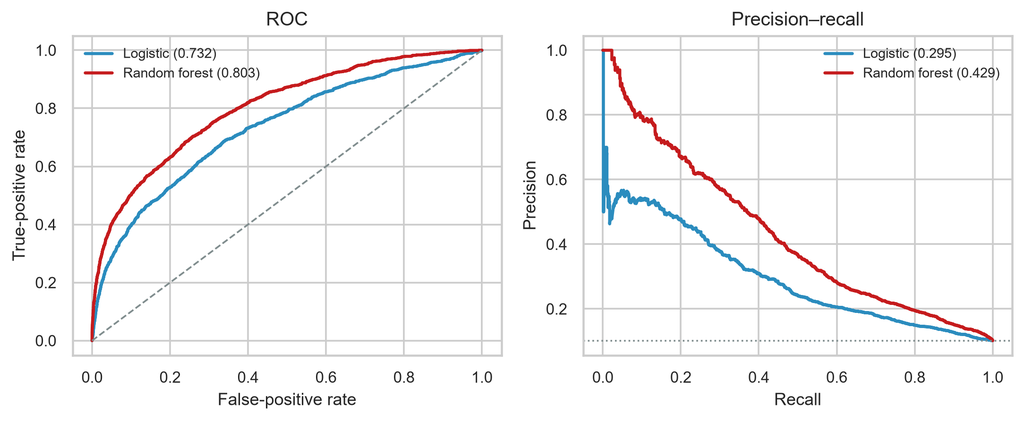

```python
cv = StratifiedKFold(5, shuffle=True, random_state=42)
models, raw_p, cal_p, metrics = {}, {}, {}, []
for name, m in [("Logistic", lr), ("Random forest", rf)]:
    folds = cross_val_score(m, Xtr, ytr, cv=cv, scoring="roc_auc", n_jobs=1)
    m.fit(Xtr, ytr)
    p = m.predict_proba(Xte)[:, 1]
    cal = CalibratedClassifierCV(m, method="sigmoid", cv=3).fit(Xtr, ytr)
    pc = cal.predict_proba(Xte)[:, 1]
    models[name], raw_p[name], cal_p[name] = m, p, pc
    metrics.append({"Model": name, "CV AUC": f"{folds.mean():.3f}±{folds.std():.3f}",
                    "AUC": f"{roc_auc_score(yte,p):.3f}", "PR-AUC": f"{average_precision_score(yte,p):.3f}",
                    "Log loss": f"{log_loss(yte,p):.3f}", "Mean p": f"{p.mean():.3f}",
                    "Cal. log loss": f"{log_loss(yte,pc):.3f}", "Cal. mean p": f"{pc.mean():.3f}"})
display(pd.DataFrame(metrics))

fig, ax = plt.subplots(1, 2, figsize=(8.5, 3.6))
for name, col in [("Logistic", BLUE), ("Random forest", RED)]:
    fpr, tpr, _ = roc_curve(yte, cal_p[name])
    ax[0].plot(fpr, tpr, color=col, lw=1.8, label=f"{name} ({roc_auc_score(yte,cal_p[name]):.3f})")
    pr, rc, _ = precision_recall_curve(yte, cal_p[name])
    ax[1].plot(rc, pr, color=col, lw=1.8, label=f"{name} ({average_precision_score(yte,cal_p[name]):.3f})")
ax[0].plot([0,1],[0,1], color=GREY, ls="--", lw=1)
ax[0].set(xlabel="False-positive rate", ylabel="True-positive rate", title="ROC")
ax[1].set(xlabel="Recall", ylabel="Precision", title="Precision–recall")
ax[1].axhline(yte.mean(), color=GREY, ls=":", lw=1)
for a in ax: a.legend(frameon=False, fontsize=8)
plt.tight_layout(); plt.show()
```

The random forest is genuinely better at ranking: test AUC 0.803 versus 0.732, PR-AUC 0.429 versus 0.295. The baseline PR of a random ranker is the churn prevalence, 0.102.

Its raw probabilities were badly inflated — mean 0.236 against a true 0.102 because of `class_weight="balanced_subsample"`. That would have nearly doubled the expected savings in the old ROI tables. A sigmoid recalibration fitted on the training folds brings the mean to 0.101 and cuts log loss from 0.342 to 0.264 with no loss of ranking. Logistic regression was already close to calibrated. **All money calculations below use the calibrated forest.**

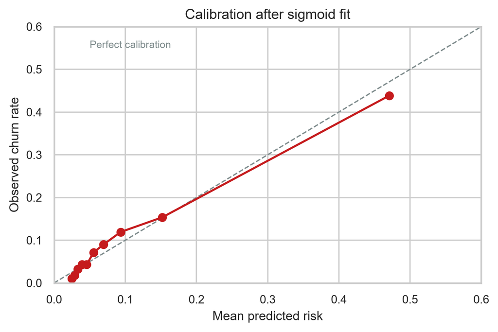

Reliability of calibrated scores: predicted versus observed churn in ten bins

| bin | pred | obs | n |
| --- | --- | --- | --- |
| (0.020399999999999998, 0.0268] | 0.025 | 0.010 | 1400 |
| (0.0268, 0.0311] | 0.029 | 0.018 | 1400 |
| (0.0311, 0.036] | 0.033 | 0.032 | 1400 |
| (0.036, 0.0422] | 0.039 | 0.043 | 1400 |
| (0.0422, 0.0501] | 0.046 | 0.043 | 1400 |
| (0.0501, 0.0615] | 0.055 | 0.071 | 1400 |
| (0.0615, 0.0792] | 0.069 | 0.090 | 1400 |
| (0.0792, 0.112] | 0.094 | 0.119 | 1400 |
| (0.112, 0.224] | 0.152 | 0.154 | 1400 |
| (0.224, 0.756] | 0.471 | 0.439 | 1400 |

```python
p_rf = cal_p["Random forest"]
rel = pd.DataFrame({"p":p_rf, "y":yte.values})
rel["bin"] = pd.qcut(rel.p, 10, duplicates="drop")
rb = rel.groupby("bin", observed=True).agg(pred=("p","mean"), obs=("y","mean"), n=("y","size"))
fig, ax = plt.subplots(figsize=(5.6,3.8))
ax.plot([0,.6],[0,.6], color=GREY, ls="--", lw=1)
ax.plot(rb.pred, rb.obs, "o-", color=RED, lw=1.6)
ax.set(xlabel="Mean predicted risk", ylabel="Observed churn rate", title="Calibration after sigmoid fit", xlim=(0,.6), ylim=(0,.6))
ax.text(.05,.55,"Perfect calibration",color=GREY,fontsize=8)
plt.tight_layout(); plt.show()
display(rb.round(3))
```

## 4.3 Thresholds and the cost of errors

A fixed 0.5 cut-off is meaningless for a 10% event. The cost-based rule from Notes 11 sets the threshold where the expected saving from a true positive exceeds the cost of contacting a false positive: contact when `p × V × s > offer + contact`. We use an illustrative offer of ₹150, a ₹10 contact cost and a 20% save rate, with `V = 12 × good-phase ARPU`. The threshold is therefore customer-specific, not a single global number.

```python
V = df.loc[Xte.index, "avg_arpu_6_7"].values * 12
s, cost = .20, 160.
with np.errstate(divide="ignore", invalid="ignore"):
    be = np.divide(cost, V*s, out=np.full_like(V, np.nan), where=V > 0)
br_all = np.nanmedian(be)
br_ch = np.nanmedian(be[yte.values == 1])
rows = []
for t in [.10, .15, .20, .30]:
    flag = p_rf >= t
    cm = confusion_matrix(yte, flag.astype(int)).ravel()
    net = (p_rf[flag]*s*V[flag] - cost).sum()
    rows.append({"Threshold": f"{t:.2f}", "Contacted": f"{flag.sum():,}",
                 "Precision": f"{precision_score(yte,flag):.3f}", "Recall": f"{recall_score(yte,flag):.3f}",
                 "TP": f"{cm[1]:,}", "FP": f"{cm[3]:,}", "Net on test (₹)": f"{net:,.0f}"})
display(pd.DataFrame(rows))
rule = (df.loc[Xte.index,"aon"]/365.25 < 1).values
print(f"Single-rule baseline (tenure < 1y): precision {precision_score(yte,rule):.3f}, recall {recall_score(yte,rule):.3f}")
print(f"Break-even risk: median customer {br_all:.3f}; median churner {br_ch:.3f}")
```

|  | Threshold | Contacted | Precision | Recall | TP | FP | Net on test (₹) |
| --- | --- | --- | --- | --- | --- | --- | --- |
| 0 | 0.10 | 3,194 | 0.274 | 0.613 | 2,320 | 874 | -35,881 |
| 1 | 0.15 | 2,032 | 0.357 | 0.509 | 1,306 | 726 | 43,290 |
| 2 | 0.20 | 1,536 | 0.415 | 0.447 | 899 | 637 | 60,403 |
| 3 | 0.30 | 1,092 | 0.493 | 0.377 | 554 | 538 | 73,897 |

```
Single-rule baseline (tenure < 1y): precision 0.160, recall 0.265
Break-even risk: median customer 0.331; median churner 0.385
```

At a 0.20 cut-off the model contacts 1,536 test customers, is 41% precise, and produces a positive expected net of about ₹60,403 on the held-out slice. The one-rule baseline contacts a similar number but is only 16% precise. Contacting everyone produces a large negative net. The specific ₹ numbers are scenarios, not forecasts — the save rate is an assumption.

## 4.4 Lift and gain

| decile | n | churners | rate | caught | lift |
| --- | --- | --- | --- | --- | --- |
| 1 | 1400 | 614 | 0.439 | 0.431 | 4.306 |
| 2 | 1400 | 215 | 0.154 | 0.581 | 1.508 |
| 3 | 1400 | 167 | 0.119 | 0.698 | 1.171 |
| 4 | 1400 | 126 | 0.090 | 0.787 | 0.884 |
| 5 | 1400 | 100 | 0.071 | 0.857 | 0.701 |
| 6 | 1400 | 60 | 0.043 | 0.899 | 0.421 |
| 7 | 1400 | 60 | 0.043 | 0.941 | 0.421 |
| 8 | 1400 | 45 | 0.032 | 0.973 | 0.316 |
| 9 | 1400 | 25 | 0.018 | 0.990 | 0.175 |
| 10 | 1400 | 14 | 0.010 | 1.000 | 0.098 |

Cumulative share of churners caught by contacting the top-scored share of the base

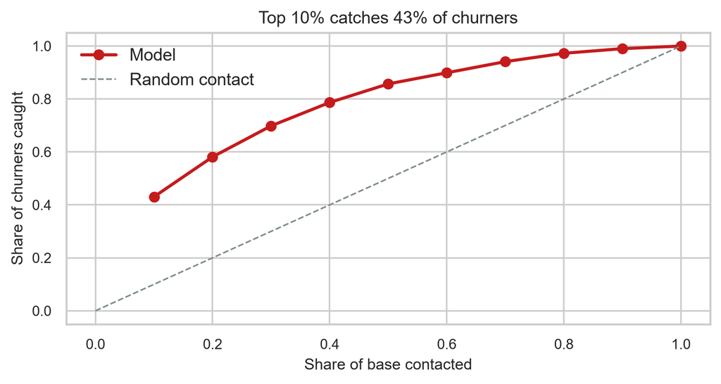

```python
ranked = pd.DataFrame({"p":p_rf,"y":yte.values}).sort_values("p",ascending=False).reset_index(drop=True)
ranked["decile"] = np.arange(len(ranked))*10//len(ranked) + 1
g = ranked.groupby("decile").agg(n=("y","size"), churners=("y","sum"), rate=("y","mean"))
g["caught"] = g.churners.cumsum()/g.churners.sum()
g["lift"] = g.rate/yte.mean()
display(g.round(3))
fig, ax = plt.subplots(figsize=(6.6,3.6))
ax.plot(np.arange(1,11)/10, g.caught, "o-", color=RED, lw=2, label="Model")
ax.plot([0,1],[0,1], color=GREY, ls="--", lw=1, label="Random contact")
ax.set(xlabel="Share of base contacted", ylabel="Share of churners caught", title=f"Top 10% catches {g.caught.iloc[0]:.0%} of churners")
ax.legend(frameon=False); plt.tight_layout(); plt.show()
```

The top score decile has 43.9% churn — 4.3× random — and captures 43% of all churners. The top three deciles capture 70%. This is the practical case for a model over blanket contact.

# 5 Prescriptive Analytics

## 5.1 Retention economics

Expected net value per contacted line is `p × s × V − (offer + contact)`. With `s = 20%` and ₹160 total cost, a customer with the **median annual value of a churner** (₹2,052) must have risk above 0.39 to justify an offer. For the **median customer in the whole base** the break-even is 0.33, and for a high-value line it is about 0.14. The old report used the *mean* churner value (₹3,164) and quoted a single 0.25 break-even; that rule is too generous for the typical line.

```python
# Rank by expected net value and cut where the budget runs out
rank = pd.DataFrame({"p":p_rf, "y":yte.values, "V":V, "hvc":df.loc[Xte.index,"is_high_value"].values})
rank["ev"] = rank.p*s*rank.V - cost
rank = rank.sort_values("ev", ascending=False).reset_index(drop=True)
rows = []
for budget in [50000, 100000, 250000]:
    k = int(budget//cost)
    sel = rank.head(k)
    realised = (sel.y*s*sel.V).sum() - k*cost
    rows.append({"Budget (₹)": f"{budget:,}", "Customers": f"{k:,}",
                 "Churners in list": f"{int(sel.y.sum()):,}", "Precision": f"{sel.y.mean():.1%}",
                 "Net on test (₹)": f"{realised:,.0f}", "ROI": f"{realised/(k*cost):.0%}"})
display(pd.DataFrame(rows))
```

|  | Budget (₹) | Customers | Churners in list | Precision | Net on test (₹) | ROI |
| --- | --- | --- | --- | --- | --- | --- |
| 0 | 50,000 | 312 | 132 | 42.3% | 136,209 | 273% |
| 1 | 100,000 | 625 | 233 | 37.3% | 171,804 | 172% |
| 2 | 250,000 | 1,562 | 482 | 30.9% | 198,493 | 79% |

Budget ranking and thresholding answer different questions. A threshold says *who qualifies*; a budget says *how many can be afforded*. Sorting by expected net value and stopping at the budget line does both, and avoids the arbitrary 0.3–0.4 thresholds read off a chart in the previous version. With a ₹1,00,000 budget the list covers 625 test lines; the table reports the net realised on the held-out set under the assumed save rate.

## 5.2 Segment allocation and the margin caveat

```python
seg_rows = []
for name, mask in [("High value", rank.hvc==1), ("Regular", rank.hvc==0)]:
    sel = rank[mask & (rank.p >= .10)].head(1000)
    if len(sel) == 0: continue
    net = (sel.y*s*sel.V).sum() - len(sel)*cost
    seg_rows.append({"Segment": name, "Contacted": f"{len(sel):,}", "Precision": f"{sel.y.mean():.1%}",
                     "Mean annual value": f"₹{sel.V.mean():,.0f}", "Net (₹)": f"{net:,.0f}"})
display(pd.DataFrame(seg_rows))
```

|  | Segment | Contacted | Precision | Mean annual value | Net (₹) |
| --- | --- | --- | --- | --- | --- |
| 0 | High value | 744 | 22.0% | ₹7,227 | 129,122 |
| 1 | Regular | 1,000 | 43.2% | ₹2,582 | 31,023 |

High-value lines repay a larger offer because their `V` is larger, not because they are intrinsically more loyal — in fact the very top ARPU decile is high-risk. The same budget should buy a cheaper, broader contact for regular lines and a costlier, personal contact for high-value ones. **ARPU is revenue, not margin.** At a 60% gross margin the break-even risk rises by 1/0.6; every rupee figure here is a top-line scenario and must be re-run with the operator’s real margin before a budget is signed.

## 5.3 Pilot design

The save rate is an assumption, not an estimate. A randomised pilot is the course’s answer. Using the Notes 07 power calculation for two proportions, detecting a rise from 18% to 22% in save rate at 80% power and 5% significance needs about 1,570 customers **per arm**; 20%→24% needs about 1,680. A 10% untreated control should be held out, guardrails (complaints, ARPU after offer, repeat churn at 90 days) recorded, and no peeking before the pre-set end date. The pilot estimates the one number — `s` — that every rupee above depends on.

```python
playbook = pd.DataFrame([
    ["1", "Top score decile + high value", "Personal call, 2 GB data or ₹300 validity", "At end of M7", "Highest expected value; break-even ≈ 0.13"],
    ["2", "Top score decile, regular value", "₹150 recharge or data bundle", "At end of M7", "Break-even ≈ 0.33 on the median line"],
    ["3", "M7 ARPU drop > ₹100, not in top decile", "SMS/IVR nudge, low-cost data trial", "Within days of M7", "Targets the change signal, not the level"],
    ["4", "New lines (< 12 months), voice-only", "Onboarding bundle + data trial", "M6–M7", "High hazard, low current value"],
    ["5", "Everyone else", "Monitor, no spend", "—", "Expected value below cost"],
], columns=["Priority", "Segment", "Action", "Timing", "Reason"])
display(playbook)
```

|  | Priority | Segment | Action | Timing | Reason |
| --- | --- | --- | --- | --- | --- |
| 0 | 1 | Top score decile + high value | Personal call, 2 GB data or ₹300 validity | At end of M7 | Highest expected value; break-even ≈ 0.13 |
| 1 | 2 | Top score decile, regular value | ₹150 recharge or data bundle | At end of M7 | Break-even ≈ 0.33 on the median line |
| 2 | 3 | M7 ARPU drop > ₹100, not in top decile | SMS/IVR nudge, low-cost data trial | Within days of M7 | Targets the change signal, not the level |
| 3 | 4 | New lines (< 12 months), voice-only | Onboarding bundle + data trial | M6–M7 | High hazard, low current value |
| 4 | 5 | Everyone else | Monitor, no spend | — | Expected value below cost |

# 6 Conclusion, Limitations and Reproducibility

The four stages produced one coherent result. **Descriptively**, churn is 10.2% in this sample, ARPU is heavily skewed, revenue is concentrated but not 80/20, and risk is U-shaped in both spend and recharge frequency. **Diagnostically**, tenure and the M6→M7 ARPU change dominate, while raw spend mostly proxies for who the customer is; the market underwent a measurable structural break in Sep-2016. **Predictively**, a calibrated random forest reaches AUC 0.803 and puts 4.3× lift in the top decile, but only after its inflated probabilities are fixed. **Prescriptively**, contact decisions must be priced per customer against calibrated risk and the *median* customer’s value, and validated with a randomised pilot before any scaling.

Three caveats matter most. This is one anonymised circle’s 2014 competition training split, not a national operator base; churn is a usage proxy, not a confirmed cancellation; and the economics rest on an assumed save rate with ARPU standing in for margin. There is also no out-of-time validation for the customer model because the data covers only three months.

## 6.1 Reproducibility appendix

Rendering `notebooks/Analysis.qmd` produces both `reports/Analysis.html` and `reports/Analysis.pdf`. The three scripts below build the processed inputs: one prepares the Kaggle customer file, two fetch and extract the TRAI series. They are run separately, before rendering, and are shown here for completeness. The Kaggle customer file is obtained with `kaggle competitions download -c telecom-churn-case-study-hackathon-gc1 -p data/raw/`, then `scripts/prepare_churn.py` writes `data/processed/churn_clean.csv`.

### 6.1.1 `scripts/prepare_churn.py`

```
"""
Build data/processed/churn_clean.csv from the raw Kaggle competition file.

The raw customer file is the labelled training split of the 2014 Kaggle
competition ``telecom-churn-case-study-hackathon-gc1``. This script adds the
derived columns used by notebooks/Analysis.qmd. It does not change any raw field
and it does not create synthetic rows.

Run:  python scripts/prepare_churn.py
"""

from __future__ import annotations

from pathlib import Path

import pandas as pd

ROOT = Path(__file__).resolve().parents[1]
RAW = ROOT / "data" / "raw" / "telecom-churn" / "train.csv"
OUT = ROOT / "data" / "processed" / "churn_clean.csv"


def main() -> None:
    raw = pd.read_csv(RAW)
    df = raw.copy()

    # 1. High value: top 30% of average monthly recharge amount in M6-M7,
    #    counting both voice/SMS recharges and data-pack recharges.
    rech_amt_6 = raw["total_rech_amt_6"] + raw["total_rech_data_6"].fillna(0) * raw["av_rech_amt_data_6"].fillna(0)
    rech_amt_7 = raw["total_rech_amt_7"] + raw["total_rech_data_7"].fillna(0) * raw["av_rech_amt_data_7"].fillna(0)
    df["avg_rech_amt_6_7"] = (rech_amt_6 + rech_amt_7) / 2.0
    cut = df["avg_rech_amt_6_7"].quantile(0.70)
    df["is_high_value"] = (df["avg_rech_amt_6_7"] >= cut).astype(int)

    # 2. Month-on-month differentials used in the diagnostic and predictive work.
    df["arpu_diff_7_6"] = df["arpu_7"] - df["arpu_6"]
    df["arpu_diff_8_7"] = df["arpu_8"] - df["arpu_7"]
    df["avg_arpu_6_7"] = (df["arpu_6"] + df["arpu_7"]) / 2.0
    df["total_og_mou_diff_8_7"] = df["total_og_mou_8"] - df["total_og_mou_7"]
    df["total_ic_mou_diff_8_7"] = df["total_ic_mou_8"] - df["total_ic_mou_7"]
```

[output cut: 11 more lines]

```
    df["has_data_plan"] = ((raw["total_rech_data_6"].fillna(0) > 0) |
                           (raw["total_rech_data_7"].fillna(0) > 0)).astype(int)
    df["data_user_label"] = df["has_data_plan"].map({1: "Data User (2G/3G)", 0: "Voice/SMS Only"})
    df["churn_label"] = df["churn_probability"].map({0: "Retained", 1: "Churned"})

    OUT.parent.mkdir(parents=True, exist_ok=True)
    df.to_csv(OUT, index=False)
    print(f"read  {RAW} ({raw.shape[0]:,} rows x {raw.shape[1]} columns)")
    print(f"wrote {OUT} ({df.shape[0]:,} rows x {df.shape[1]} columns)")
    print(f"high-value cut at Rs {cut:.2f}: {df.is_high_value.sum():,} rows ({df.is_high_value.mean():.1%})")
    print(f"data-plan flag: {df.has_data_plan.sum():,} rows ({df.has_data_plan.mean():.1%})")


if __name__ == "__main__":
    main()
```

### 6.1.2 `scripts/fetch_trai.py`

```
"""
Fetch the official TRAI Performance Indicator reports (quarterly + yearly)
from the TRAI publications index into data/raw/trai/.

The index is a Drupal view with 30 items per page. Report titles encode the
quarter; we parse them into (year, quarter-end month) and keep QE Mar/Jun/Sep/Dec
from 2014 onwards. A manifest with the source URL and SHA-256 is written so the
extraction step can be audited against the exact files used.

Run:  python scripts/fetch_trai.py
"""

from __future__ import annotations

import hashlib
import html
import re
import time
import warnings
from pathlib import Path

import requests

warnings.filterwarnings("ignore", message="Unverified HTTPS request")

ROOT = Path(__file__).resolve().parents[1]
RAW = ROOT / "data" / "raw" / "trai"
INDEX = "https://trai.gov.in/release-publication/reports/performance-indicators-reports"
HEADERS = {"User-Agent": "Mozilla/5.0 (Windows NT 10.0; Win64; x64)"}

# Explicit skip list: reports that are not performance-indicator quarterlies or
# yearlies (errata, QoS surveys, press kits, etc.).
SKIP_PAT = re.compile(r"errata|survey|assessment|custome|congestion|press kit|qos", re.I)

MONTHS = {
    "march": 3, "mar": 3,
    "june": 6, "jun": 6,
    "september": 9, "sep": 9, "sept": 9,
    "december": 12, "dec": 12, "decemberr": 12,
}
```

[output cut: 99 more lines]

```
        manifest.append({
            "filename": rep["filename"], "quarter_end": f"{rep['year']}-{rep['month']:02d}",
            "title": rep["title"], "release_date": rep["release_date"], "url": rep["url"],
            "bytes": path.stat().st_size, "sha256": sha256(path),
        })
        print(f"   ok {path.stat().st_size/1e6:.1f} MB", flush=True)

    import pandas as pd
    out = RAW / "trai_download_manifest.csv"
    pd.DataFrame(manifest).to_csv(out, index=False)
    print(f"manifest -> {out}", flush=True)


if __name__ == "__main__":
    main()
```

### 6.1.3 `scripts/build_trai_series.py`

```
"""
Extract a quarterly macro series from the TRAI Performance Indicator PDFs.

Every value is read from the report text and stored together with the page it
came from. No value is hard-coded. Run scripts/fetch_trai.py first.

Run:  python scripts/build_trai_series.py
"""

from __future__ import annotations

import json
import re
import warnings
from pathlib import Path

import pandas as pd
import pypdf

warnings.filterwarnings("ignore")

ROOT = Path(__file__).resolve().parents[1]
RAW = ROOT / "data" / "raw" / "trai"
OUT = ROOT / "data" / "processed" / "trai_quarterly.csv"

RUPEE = r"(?:Rs\.?|`|₹)\s*"
NUM = r"([\d,]+(?:\.\d+)?)"


def num(s):
    return float(str(s).replace(",", ""))


def first(patterns, pages, flags=re.I | re.S):
    """Return (value_as_float, page_number) for the first match of any pattern."""
    for pattern in patterns:
        for i, text in pages:
            m = re.search(pattern, text, flags)
            if m:
                return num(m.group(1)), i
```

[output cut: 82 more lines]

```
    df = pd.DataFrame(rows)
    df["quarter_end"] = df.source_file.str.extract(r"QE_([A-Za-z]+)_(\d{4})").apply(
        lambda r: f"{r[1]}-{ {'Mar':3,'Jun':6,'Sep':9,'Dec':12}[r[0]]:02d}" if isinstance(r[0], str) else None, axis=1)
    df = df.sort_values("quarter_end").reset_index(drop=True)
    OUT.parent.mkdir(parents=True, exist_ok=True)
    df.to_csv(OUT, index=False)
    print(df[["quarter_end", "arpu_blended", "arpu_prepaid", "arpu_postpaid", "mou",
              "wireless_subs_m", "data_gb", "data_basis", "rs_per_gb"]].to_string(index=False))
    print("\nnon-null counts:")
    print(df.notna().sum().to_string())
    print(f"\nwrote {OUT} ({len(df)} quarters)")


if __name__ == "__main__":
    main()
```